# Le paradoxe de l’anniversaire ou l’art de tromper son intuition

Jordan

01/02/2020

# 1 Le paradoxe de l’anniversaire, c’est quoi ?

L’idée de ce poste est de revenir sur la réponse à ce paradoxe et la rendre plus accessible en décomposant le problème. Ce paradoxe repose sur une question simple : **combien de personnes faut-il rassembler dans une pièce pour avoir avoir 1 chance sur 2 que deux individus aient la même date d’anniversaire?** La réponse ne l’est pas pour autant, du moins elle n’est pas intuitive : **23**.  
Sur 365 dates possibles du 1er janvier au 31 décembre (en excluant les années bissextiles par simplification), il suffit de 23 personnes, donc 23 dates pour avoir 1 chance sur 2, qu’au moins deux personnes partagent le même jour d’anniversaire.

Le graphique avec l’ensemble des réponses :

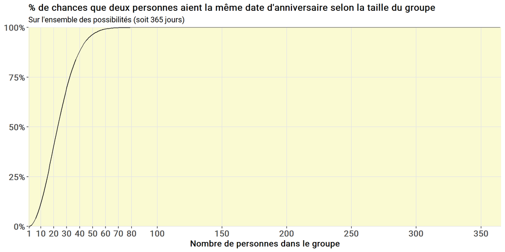

```r
  # Matrice vide
  demo <- data.frame(
    jour = seq(1, 365, 1),
    nb_paires = numeric(365),
    proba_evenement = numeric(365),
    proba_supposee = numeric(365),
    stringsAsFactors = FALSE
  )

  demo <- demo %>%
    mutate(nb_paires = jour * (jour - 1) /2,
           proba_evenement = 1 - (364/365) ** nb_paires,
           proba_supposee = 1 - ((365+1-jour)/365))

  ggplot(demo)+
    geom_line(aes(x = jour, y = proba_evenement))+
    scale_x_continuous(expand=c(0,0.5), breaks = c(1,10,20,30,40,50,60,70,80,100,150,200,250,300,350), name = "Nombre de personnes dans le groupe")+
    scale_y_continuous(expand=c(0,0),labels = scales:::percent_format(accuracy = 1), name = NULL)+
    labs(title = "% de chances que deux personnes aient la même date d'anniversaire selon la taille du groupe",
         subtitle = "Sur l'ensemble des possibilités (soit 365 jours)")+
    theme(text = element_text(family = "Roboto"),
        plot.title = element_text(size = 13, face = "bold"),
        panel.background = element_rect(fill = "lightgoldenrodyellow"),
        axis.text = element_text(face = "bold", size = 12),
        axis.title = element_text(face = "bold", size = 12),
        panel.grid.major = element_line(colour = "grey90"),
        panel.grid.minor = element_blank())
```

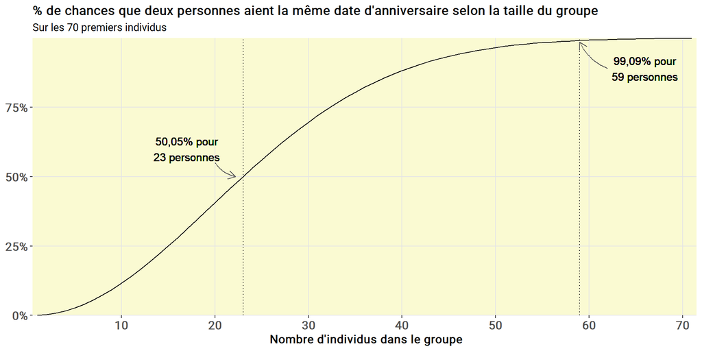

```r
ggplot(demo %>% filter(jour<=71))+
  geom_line(aes(x = jour, y = proba_evenement))+
  # Annotation 1
  geom_vline(aes(xintercept= 23, ), lty = 3)+
  geom_text(aes(x = 17, y = 0.6, label = "50,05% pour\n23 personnes"), size = 4)+
  geom_curve(aes(x = 20, y = 0.55, xend = 22.2, yend = 0.5),
                           colour = "#555555",
                           curvature = 0.2,
                           size=0.5,
             arrow = arrow(length = unit(0.03, "npc")))+
  # Annotation 2
  geom_vline(aes(xintercept= 59, ), lty = 3)+
  geom_text(aes(x = 66, y = 0.89, label = "99,09% pour\n59 personnes"), size = 4)+
  geom_curve(aes(x = 62, y = 0.89, xend = 59, yend = 0.985),
                           colour = "#555555",
                           curvature = -0.2,
                           size=0.5,
             arrow = arrow(length = unit(0.03, "npc")))+

  scale_x_continuous(expand=c(0,0.5), breaks = seq(1,80,10)-1, name = " Nombre d'individus dans le groupe") +
  scale_y_continuous(expand=c(0,0),labels = scales:::percent_format(accuracy = 1), name = NULL)+
  labs(title = "% de chances que deux personnes aient la même date d'anniversaire selon la taille du groupe",
       subtitle = "Sur les 70 premiers individus")+
  theme(text = element_text(family = "Roboto"),
        plot.title = element_text(size = 13, face = "bold"),
        panel.background = element_rect(fill = "lightgoldenrodyellow"),
        axis.text = element_text(face = "bold", size = 12),
        axis.title = element_text(face = "bold", size = 12),
        panel.grid.major = element_line(colour = "grey90"),
        panel.grid.minor = element_blank())
```

# 2 La preuve par le bootsrap

Avant de recourir à la formule mathématique, on peut se persuader du résultat en simulant la situation, puis en la répétant un grand nombre de fois afin d’avoir des résultats robustes. Ainsi, on tire les dates une par une, avec remise, jusqu’à temps d’en avoir une déjà piochée, et on stocke le résultat. On répète l’opération 15 000 fois. Voici le résultat :

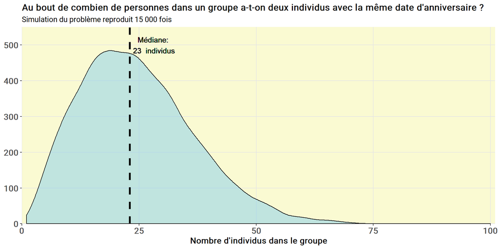

```r
 # Création d'un dataframe vide pour accueillir les résultats du bootstrap
  liste <- data.frame(resultat = integer(15000),
                      stringsAsFactors = FALSE)

  # Boucle bcp plus effice (25 fois plus rapide)
  for (j in seq(1,15000,1)){

    # Création d'un dataframe vide avec le nombre max de tirage possible (365), le jour tiré, et si la date a déjà été tirée ?
    calendrier <- data.frame(jour = seq(1,365,1),
                             tirage = integer(365),
                             evenement = integer(365),
                             stringsAsFactors = FALSE) # Matrice vide

      # tirage d'un jour aléatoire sans remise
      calendrier[,2] <- sample(calendrier[, 1] , size = 365, replace = TRUE)
      # Premier jour déjà tiré
      liste[j,1] <- min(calendrier[duplicated(calendrier$tirage),1])
  }

  # Graphique des résultats
  ggplot(data = liste)+
    geom_density(aes(x = resultat, stat(count)), fill = "skyblue", alpha = 0.5)+
    geom_vline(aes(xintercept = median(resultat)),linetype = 2, size = 1.25)+
    geom_text(aes(x=median(resultat)+5, y = 500, label = paste("Médiane:\n",median(resultat)," individus")))+
    scale_x_continuous(limits=c(1,100), expand = c(0,1),name = "Nombre d'individus dans le groupe")+
    scale_y_continuous(limits=c(0,550), expand = c(0,0), name = NULL)+
    labs(title = "Au bout de combien de personnes dans un groupe a-t-on deux individus avec la même date d'anniversaire ?",
        subtitle = "Simulation du problème reproduit 15 000 fois")+
    theme(text = element_text(family = "Roboto"),
      plot.title = element_text(size = 13, face = "bold"),
      panel.background = element_rect(fill = "lightgoldenrodyellow"),
      axis.text = element_text(face = "bold", size = 12),
      axis.title = element_text(face = "bold", size = 12),
      panel.grid.major = element_line(colour = "grey90"),
      panel.grid.minor = element_blank())
```

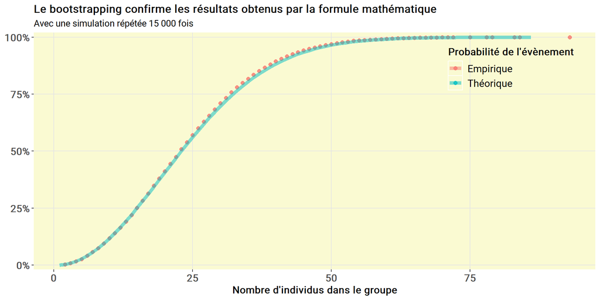

```r
  # Résultats cumulés pour pouvoir comparer les distributions
  cumule <-  liste %>% group_by(resultat) %>% summarize(n=n()) %>% ungroup() %>% mutate(cumsum = cumsum(n))
  # Comparaison avec les probas attendues par la formule
  ggplot() +
    geom_point(data = cumule, aes(x = resultat, y = cumsum/15000, color = "Empirique"), alpha = 0.8, size = 2) +
    geom_line(data = demo %>% filter(jour <= 86), aes(x = jour, y = proba_evenement, color = "Théorique"), alpha = 0.5, size = 2)+
    scale_y_continuous(expand=c(0,0.02),labels = scales:::percent_format(accuracy = 1))+
    scale_color_discrete(name = "Probabilité de l'évènement")+
    labs(title = "Le bootstrapping confirme les résultats obtenus par la formule mathématique",
        subtitle = "Avec une simulation répétée 15 000 fois",
        x = "Nombre d'individus dans le groupe",
        y = NULL)+
      theme(text = element_text(family = "Roboto"),
            plot.title = element_text(size = 13, face = "bold"),
            panel.background = element_rect(fill = "lightgoldenrodyellow"),
            axis.text = element_text(face = "bold", size = 12),
            axis.title = element_text(face = "bold", size = 12),
            panel.grid.major = element_line(colour = "grey90"),
            panel.grid.minor = element_blank(),
            legend.position = c(0.85,0.85),
            legend.background = element_rect(fill = "transparent"),
            legend.title = element_text(face = "bold",size = 12),
            legend.text = element_text(size = 12),
            legend.key = element_rect(fill = "transparent"))
```

# 3 Comment expliquer ce résultat contre-intuitif ?

La représentation mentale que l’on se fait du problème est souvent biaisée en omettant un de ses mécanismes sous-jacents. Et même quand celui-ci est connnu, le cerveau humain a du mal à se représenter la situation.  
Le problème peut être aborder en retournant le problème en s’appuyant sur l’évènement opposé (1 - l’évènement étudié), autrement dit, l’évènement “deux individus n’ont pas la même date d’anniversaire”.

- Le premier individu a $\frac{365}{365}$ chances de ne pas avoir la même date d’anniversaire que quelqu’un d’autres.
- La probabilité que le second individu est une date d’anniversaire différente d’un autre est la suivante : $\frac{365-1}{365}$
- La difficulté intervient à partir du 3e : intuitivement on serait tenter de dire $\frac{365-2}{365}$. Mais en faisant ça, on ignore le fait que pour que cet évènement se réalise, il faut aussi que le deuxième individu n’est pas la même date que le premier, soit mathématiquement : $\frac{365}{365}+(\frac{365}{365}\times\frac{364}{365})+(\frac{365}{365}\times\frac{364}{365}\times\frac{363}{365})$.

Le problème peut être appréhender différemment, avec toujours comment point de départ la proba $\frac{364}{365}$, la proba que le deuxième individu n’est pas la même date que le premier. On cherche ensuite à considérer l’ensemble des combinaisons de deux individus possibles. Il s’agit ici d’un calcul de combinaisons : pour $n$ individus, le nombre de paires est égal à $(n-1)\times\frac{n}{2}$. Comme on parle d’évènements indépendants (du moins c’est l’hypothèse retenue, plutôt réaliste), les probabilités sont multiplicatives. Ainsi pour $n$ paires, la proba sera $\frac{364}{365}^{n}$.  
Pour revenir au paradoxe initial, on inverse la probabilité obtenue. Les résultats sont présentés dans le graphique ci-dessous :

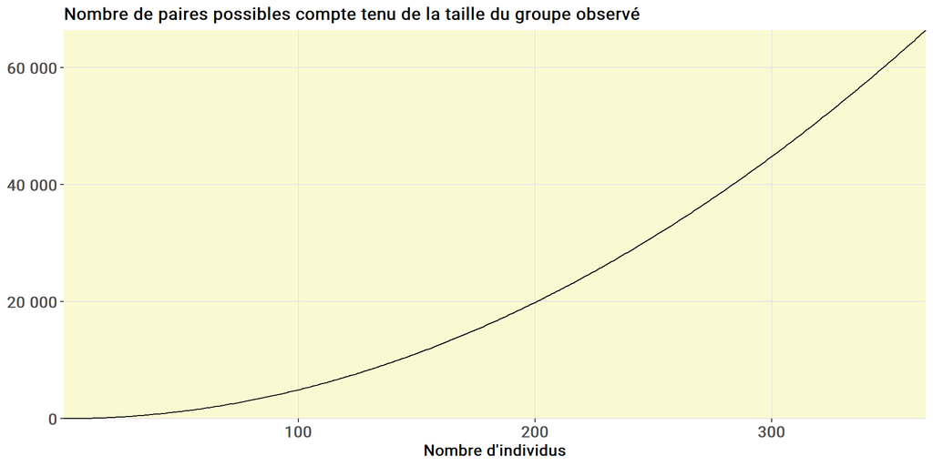

```r
  # Matrice vide
  demo <- data.frame(
    jour = seq(1, 365, 1),
    nb_paires = numeric(365),
    proba_evenement = numeric(365),
    proba_supposee = numeric(365),
    stringsAsFactors = FALSE
  )

  demo <- demo %>%
    # filter(jour <= 100) %>%
    mutate(nb_paires = jour * (jour - 1) /2,
           proba_evenement = 1 - (364/365) ** nb_paires,
           proba_supposee = 1 - ((365+1-jour)/365)) %>%
    pivot_longer(c(proba_evenement,proba_supposee),names_to = "type_proba",values_to = "proba")

  # Nombre de paires possibles
    ggplot(demo)+
    geom_line(aes(x = jour, y = nb_paires))+
    scale_x_continuous(expand=c(0,0))+
    scale_y_continuous(expand = c(0,0),
                       labels = function(x) format(x, big.mark = " ",
                                                       scientific = FALSE))+
    labs(title="Nombre de paires possibles compte tenu de la taille du groupe observé",
         x = "Nombre d'individus",
         y=NULL)+
    theme(text = element_text(family = "Roboto"),
      plot.title = element_text(size = 13, face = "bold"),
      panel.background = element_rect(fill = "lightgoldenrodyellow"),
      axis.text = element_text(face = "bold", size = 12),
      axis.title = element_text(face = "bold", size = 12),
      panel.grid.major = element_line(colour = "grey90"),
      panel.grid.minor = element_blank())
```

La réalité est donc bien différente de notre perception, qui tend à croire que la probabilité croît linéairement, et donc qu’il faut 182 individus (la moitié des dates possibles dans une année) pour atteindre la probabilité de 50% d’observer l’évènement.

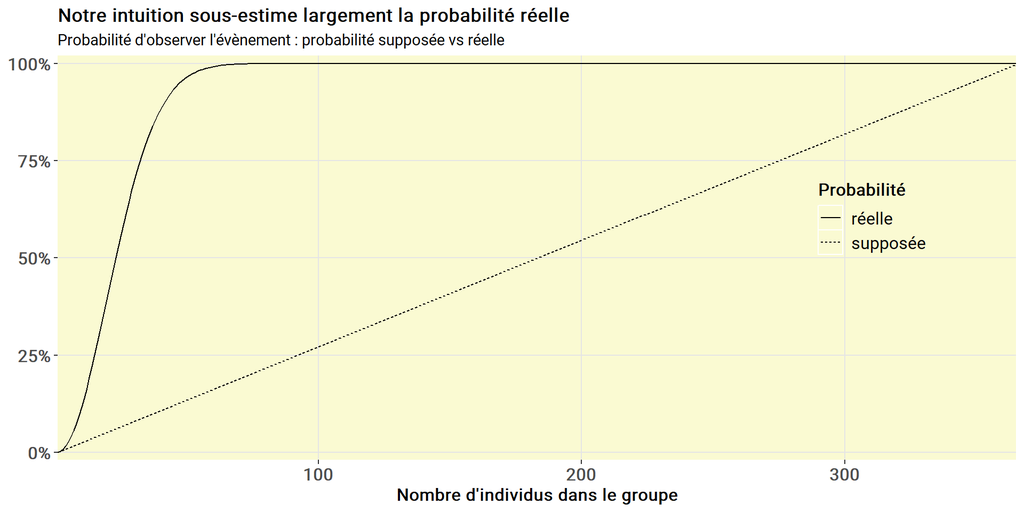

```r
  # Nombre de paires possibles vs nombre de paires imaginées (à faire sous forme d'animation, d'abord l'imaginée, puis la réelle)
    # Pas la bonne corube représentée, ou alors il faut changer le titre sinon on se répète avec les premiers graphes
    ggplot(demo,aes(x=jour, y=proba, group = type_proba))+
    geom_line(aes(linetype=type_proba))+
    scale_x_continuous(expand = c(0,0),limits = c(1,365))+
    scale_y_continuous(expand=c(0,0.02),labels = scales:::percent_format(accuracy = 1))+
    scale_linetype_discrete(name = "Probabilité ", labels = (c("réelle","supposée")))+
    labs(title = "Notre intuition sous-estime largement la probabilité réelle",
         subtitle = "Probabilité d'observer l'évènement : probabilité supposée vs réelle",
         x = "Nombre d'individus dans le groupe",
         y = NULL)+
    theme(text = element_text(family = "Roboto"),
      plot.title = element_text(size = 13, face = "bold"),
      panel.background = element_rect(fill = "lightgoldenrodyellow"),
      axis.text = element_text(face = "bold", size = 12),
      axis.title = element_text(face = "bold", size = 12),
      panel.grid.major = element_line(colour = "grey90"),
      panel.grid.minor = element_blank(),
      legend.position = c(0.85,0.60),
      legend.background = element_rect(fill = "transparent"),
      legend.title = element_text(face = "bold",size = 12),
      legend.text = element_text(size = 12),
      legend.key = element_rect(fill = "transparent"))
```